# MLiC_HW3

Ali Yesilkanal

December 1, 2017

##### **GOAL:** To build a model that predicts incidence rate of melanoma for each county

I first started with the two given features to build my model - (1) Average household income described as “Value(Dollars)”, and (2) Amount of sunlight per county described as “Avg Daily Sunlight (KJ/m²)”. It should be noted that the Ave Daily Sunlight parameter is an aggregate of all the data collected in a particular county over the years. Outcome data for this training set is the “Age-Adjusted Incidence Rate” data associated with each county.

To create the feature matrix for model training, I used the “FIPS” county code to merge the data frames containing the outcome parameter as well as the two features described above. Approximately one third of the counties did not have melanoma incidence rate information, which appears as an “NA” value in the “Age-Adjusted Incidence Rate” outcome column. For simplicity, I removed all the data that had NA values before training my model, which left me with a 2044 x 2 feature matrix.

```
##    FIPS Age-Adjusted Incidence Rate Value (Dollars)
## 1 10001                        26.1           64252
## 2 10003                        27.5           81298
## 3 10005                        38.4           63311
## 4 11001                         8.8           85321
## 5 12001                        26.5           65088
## 6 12003                        14.6           58995
## 7 12005                        19.8           57635
## 8 12007                        24.9           56406
##   Avg Daily Sunlight (KJ/m²)
## 1                   15809.41
## 2                   15335.57
## 3                   15936.01
## 4                   15265.36
## 5                   18028.29
## 6                   17777.25
## 7                   17953.44
## 8                   17865.16
```

I used three methods for training my model: (1) random forest (ranger), (2) linear model, (3) generalized linear model. For each model, I incorporated 5-fold cross-validation step and trained the models as regression. The following is the comparison of the r2 values for all three models. These initial models did not fit the data well based on the two features we provided.

```
##
## Call:
## summary.resamples(object = resamples(list(ranger = ranger1.1, lm =
##  lm1.1, glm = glm1.1)))
##
## Models: ranger, lm, glm
## Number of resamples: 5
##
## MAE
##            Min.  1st Qu.   Median     Mean  3rd Qu.     Max. NA's
## ranger 5.187754 5.249085 5.446300 5.396004 5.468237 5.628642    0
## lm     5.213013 5.274481 5.503066 5.433640 5.552143 5.625495    0
## glm    5.168577 5.388414 5.389613 5.431912 5.500034 5.712923    0
##
## RMSE
##            Min.  1st Qu.   Median     Mean  3rd Qu.     Max. NA's
## ranger 6.617176 7.297401 7.308482 7.271961 7.366687 7.770057    0
## lm     6.885412 7.090235 7.109563 7.306107 7.597803 7.847521    0
## glm    6.632576 6.967483 7.000774 7.285635 7.301217 8.526127    0
##
## Rsquared
##              Min.    1st Qu.     Median       Mean    3rd Qu.      Max.
## ranger 0.09678495 0.09735736 0.09767436 0.11408995 0.12626647 0.1523666
## lm     0.05884999 0.05905589 0.09233944 0.08625013 0.10353035 0.1174750
## glm    0.06364607 0.06696041 0.07904338 0.08664739 0.09588459 0.1277025
##        NA's
## ranger    0
## lm        0
## glm       0
```

In order to increase the r2 values, I wanted to add more features to the training matrix. The extra credit portion of the assignment suggested that we include the incedence data from the neighboring counties. For this, I first downloaded the neighboring county information from the US Census Bureau’s website: https://www.census.gov/geo/reference/county-adjacency.html . County adjacency data look like the following:

```
##                    V1   V2                    V3    V4
## 1  Autauga County, AL 1001    Autauga County, AL  1001
## 2                       NA    Chilton County, AL  1021
## 3                       NA     Dallas County, AL  1047
## 4                       NA     Elmore County, AL  1051
## 5                       NA    Lowndes County, AL  1085
## 6                       NA Montgomery County, AL  1101
## 7  Baldwin County, AL 1003    Baldwin County, AL  1003
## 8                       NA     Clarke County, AL  1025
## 9                       NA   Escambia County, AL  1053
## 10                      NA     Mobile County, AL  1097
## 11                      NA     Monroe County, AL  1099
## 12                      NA Washington County, AL  1129
## 13                      NA   Escambia County, FL 12033
## 14 Barbour County, AL 1005    Barbour County, AL  1005
## 15                      NA    Bullock County, AL  1011
## 16                      NA       Dale County, AL  1045
## 17                      NA      Henry County, AL  1067
## 18                      NA       Pike County, AL  1109
## 19                      NA    Russell County, AL  1113
## 20                      NA       Clay County, GA 13061
```

I merged the adjacency data frame with the incidence rates from the melanomav08 data and created 3 new features for each county FIPS: (1) mean incidence rate of the neighboring counties (“neighbor_ave_incedence”), (2) minimum incedence rate in the neighbors (“neighbor_min_incedence”), and (3) maximum incedence rate in the neighbors (“neighbor_max_incedence”).

Since melanoma is biologically related to UV exposure, I also wanted to see if county-based UV exposure data would be a better predictor than the average daily sunlight data. I downloaded county UV exposure data from https://gis.cancer.gov/tools/uv-exposure/ and merged it with my training matrix. I also created 3 more features based on UV-exposure of the neighboring counties, the same way I generated the neighboring county incidence rates: 1) mean UV exposure of the neighboring counties (“neighbor_ave_uv”), (2) minimum uv exposure in the neighbors (“neighbor_min_uv”), and (3) maximum uv exposure in the neighbors (“neighbor_max_uv”).

After removing rows that have NA values, my final feature matrix had 1833 counties (rows) and 9 features (columns).

```r
head(new_feat_mat)
```

```
##    FIPS Age-Adjusted Incidence Rate Value (Dollars)
## 1 10001                        26.1           64252
## 2 10003                        27.5           81298
## 3 10005                        38.4           63311
## 4 11001                         8.8           85321
## 5 12001                        26.5           65088
## 6 12003                        14.6           58995
##   Avg Daily Sunlight (KJ/m²) neighbor_ave_incedence neighbor_min_incedence
## 1                   15809.41               29.02222                   17.1
## 2                   15335.57               27.67500                   18.6
## 3                   15936.01               30.94286                   19.4
## 4                   15265.36               12.36667                    6.7
## 5                   18028.29               24.67500                   19.4
## 6                   17777.25               23.85000                   13.6
##   neighbor_max_incedence UV_ Wh/m² neighbor_ave_uv neighbor_min_uv
## 1                   43.7   4080.90        4068.016         4035.98
## 2                   34.2   4038.46        4028.821         3973.11
## 3                   43.7   4102.60        4099.997         4060.54
## 4                   18.8   4100.16        4098.677         4068.84
## 5                   37.6   4709.47        4707.177         4659.13
## 6                   37.6   4638.78        4645.868         4606.89
##   neighbor_max_uv
## 1         4102.60
## 2         4080.90
## 3         4122.51
## 4         4110.57
## 5         4764.52
## 6         4674.96
```

```r
dim(new_feat_mat)
```

```
## [1] 1833   11
```

I trained my three models on this new data frame and the fitness of all three models increased drastically (r2 from ~0.10 to ~0.60):

```
##
## Call:
## summary.resamples(object = resamples(list(ranger = ranger2.1, lm =
##  lm2.1, glm = glm2.1)))
##
## Models: ranger, lm, glm
## Number of resamples: 5
##
## MAE
##            Min.  1st Qu.   Median     Mean  3rd Qu.     Max. NA's
## ranger 3.306170 3.408022 3.499858 3.555293 3.645641 3.916773    0
## lm     3.246176 3.249749 3.258145 3.353500 3.439156 3.574277    0
## glm    3.260728 3.315380 3.352279 3.341081 3.362275 3.414741    0
##
## RMSE
##            Min.  1st Qu.   Median     Mean  3rd Qu.     Max. NA's
## ranger 4.377366 4.734790 4.758488 4.905839 5.146440 5.512109    0
## lm     4.276248 4.329972 4.580455 4.574281 4.665895 5.018833    0
## glm    4.379796 4.383414 4.414906 4.549063 4.562435 5.004765    0
##
## Rsquared
##             Min.   1st Qu.    Median      Mean   3rd Qu.      Max. NA's
## ranger 0.5619403 0.5793474 0.5925233 0.5919982 0.6034270 0.6227528    0
## lm     0.6242370 0.6401637 0.6409871 0.6472480 0.6427223 0.6881299    0
## glm    0.6198923 0.6202324 0.6302054 0.6488505 0.6779865 0.6959358    0
```

Interestingly, linear models (lm and glm) performed better than the random forest model with this training matrix.

Among all 9 of the features I used to train my models, the most important feature was the average incidence rate of melanoma in the neighboring counties (“neighbor_ave_incidence”). Even though melanoma is related to UV exposure in most cases, neither average daily sunlight nor the UV exposure related features were predictive of melanoma risk.

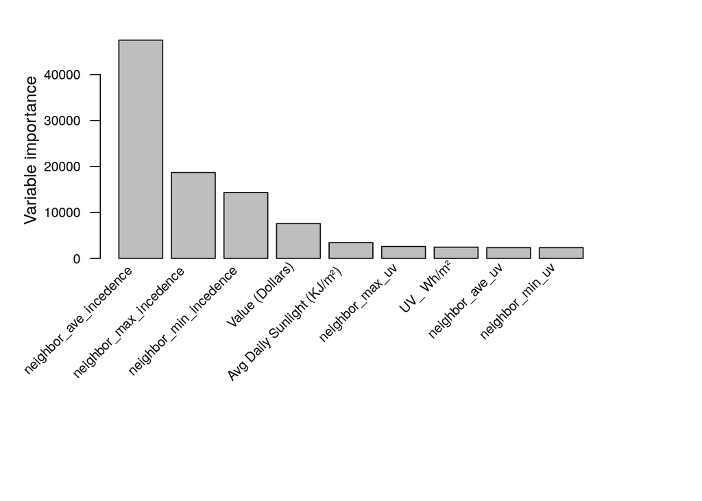